# Linear Regression

Here we analyze a data set consisting of a crash score as response and different categorical predictors. We will fit a multiple linear regression model. I obtained the data set from the PA Exam (Predictive Analytics) June 13, 2019 Project Report Template Society of Actuaries (SOA):

https://www.soa.org/globalassets/assets/files/edu/2019/exam-pa-06-14-model-solution.pdf

Note that here I performed a different analysis.

A short description of the data set follows:

Variable name // Description // Variable Domain

Crash Score// Measures the extent of the crash using factors such as number of injuries and fatalities, the number of vehicles involved, and other factors. // A positive number with two decimal places.

Year// Calender year of the crash. //Integer 2014-2019

Month// Calendar month of the crash. //Integer 1-12 (1=January, 12=December)

Time_of_day //In four hours blocks.// Integer 1-6 (1=midnight to 4am, 6=8pm to midnight)

Rd_Feature // Special feature of the road where the crash occurred. // NONE-no special feature. INTERSECTION - the meeting of at least two roads. RAMP - exit or entrance ramp to a controlled access road. DRIVEWAY - entrance to home or business. OTHER

Rd_Character // Description of the road where the crash occurred. // STRAIGHT- LEVEL – no curves or hills. STRAIGHT-GRADE – no curves, but on a hill (up or down). STRAIGHT-OTHER. CURVE-LEVEL – on a curve but no hill. CURVE-GRADE – on a curve and on a hill. CURVE-OTHER. OTHER

Rd_Configuration// Design of the road. // TWO-WAY-PROTECTED-MEDIAN –Traffic in both directions, separated with a barrier. TWO-WAY-UNPROTECTED-MEDIAN – separated but with no barrier. TWO-WAY-NO-MEDIAN– no separation. ONE-WAY. UNKNOWN

Rd_Surface// Material used for the road surface. // SMOOTH ASPHALT. COARSE ASPHALT. CONCRETE. GROOVED CONCRETE. OTHER

Rd_Conditions// Condition of the road.// DRY WET ICE-SNOW-SLUSH OTHER

Light// Lighting. // DAYLIGHT DARK-NO-LIT – no street lamps in area DARK-LIT DUSK DAWN OTHER

Weather// Weather conditions. // CLEAR RAIN CLOUDY SNOW OTHER.

Traffic_Control// Any items that control traffic flow. // SIGNAL – lighted stop/go signal STOPSIGN YIELD  
NONE OTHER.

Work_Area// Was the crash in a work area? // YES/NO.

```r
df <- read.csv('June_13_data.csv')
df
```

| Crash_Score | year | Month | Time_of_Day | Rd_Feature | Rd_Character | Rd_Class | Rd_Configuration | Rd_Surface | Rd_Conditions | Light | Weather | Traffic_Control | Work_Area |
| --- | --- | --- | --- | --- | --- | --- | --- | --- | --- | --- | --- | --- | --- |
| 6.56 | 2016 | 6 | 2 | NONE | STRAIGHT-LEVEL | STATE HWY | TWO-WAY-PROTECTED-MEDIAN | SMOOTH ASPHALT | DRY | DAYLIGHT | CLEAR | NONE | NO |
| 6.53 | 2016 | 6 | 3 | NONE | STRAIGHT-LEVEL | OTHER | TWO-WAY-NO-MEDIAN | COARSE ASPHALT | DRY | DAYLIGHT | CLEAR | NONE | NO |
| 1.58 | 2016 | 6 | 5 | NONE | STRAIGHT-LEVEL | STATE HWY | TWO-WAY-NO-MEDIAN | SMOOTH ASPHALT | DRY | DARK-NOT-LIT | CLEAR | NONE | NO |
| 7.15 | 2016 | 6 | 3 | NONE | STRAIGHT-LEVEL | OTHER | TWO-WAY-NO-MEDIAN | SMOOTH ASPHALT | DRY | DAYLIGHT | CLEAR | NONE | NO |
| 9.57 | 2016 | 6 | 6 | NONE | STRAIGHT-LEVEL | OTHER | TWO-WAY-NO-MEDIAN | COARSE ASPHALT | DRY | DARK-LIT | CLEAR | NONE | NO |
| 8.14 | 2016 | 6 | 3 | NONE | STRAIGHT-LEVEL | OTHER | TWO-WAY-NO-MEDIAN | SMOOTH ASPHALT | DRY | DAYLIGHT | CLEAR | NONE | NO |
| 6.06 | 2016 | 6 | 5 | INTERSECTION | STRAIGHT-LEVEL | STATE HWY | TWO-WAY-NO-MEDIAN | SMOOTH ASPHALT | DRY | DAYLIGHT | CLEAR | SIGNAL | NO |
| 2.11 | 2016 | 6 | 4 | NONE | STRAIGHT-GRADE | STATE HWY | TWO-WAY-UNPROTECTED-MEDIAN | SMOOTH ASPHALT | DRY | DAYLIGHT | CLEAR | NONE | NO |
| 4.37 | 2016 | 6 | 3 | RAMP | STRAIGHT-OTHER | US HWY | ONE-WAY | SMOOTH ASPHALT | DRY | DAYLIGHT | CLEAR | SIGNAL | NO |
| 9.00 | 2016 | 6 | 4 | NONE | STRAIGHT-LEVEL | STATE HWY | TWO-WAY-NO-MEDIAN | SMOOTH ASPHALT | DRY | DAYLIGHT | CLEAR | NONE | YES |

[output cut: 990 more lines]

We will consider only four variables. Time of Day, Rd_feature, Rd_configuration, and Traffic_control.

```r
df <- df[,c(1,4,5,8,13)]
df[,-1] <- lapply(df[,-1], factor)
str(df)
```

```
'data.frame':   23137 obs. of  5 variables:
 $ Crash_Score     : num  6.56 6.53 1.58 7.15 9.57 8.14 6.06 2.11 4.37 9 ...
 $ Time_of_Day     : Factor w/ 6 levels "1","2","3","4",..: 2 3 5 3 6 3 5 4 3 4 ...
 $ Rd_Feature      : Factor w/ 5 levels "DRIVEWAY","INTERSECTION",..: 3 3 3 3 3 3 2 3 5 3 ...
 $ Rd_Configuration: Factor w/ 5 levels "ONE-WAY","TWO-WAY-NO-MEDIAN",..: 3 2 2 2 2 2 2 4 1 2 ...
 $ Traffic_Control : Factor w/ 5 levels "NONE","OTHER",..: 1 1 1 1 1 1 3 1 3 1 ...
```

```r
contrasts(df[,3])
```

```
             INTERSECTION NONE OTHER RAMP
DRIVEWAY                0    0     0    0
INTERSECTION            1    0     0    0
NONE                    0    1     0    0
OTHER                   0    0     1    0
RAMP                    0    0     0    1
```

```r
names(df)
```

```
[1] "Crash_Score"      "Time_of_Day"      "Rd_Feature"       "Rd_Configuration"
[5] "Traffic_Control"
```

```r
fitmodel <- lm(Crash_Score~.,data=df)
summary(fitmodel)
```

```
Call:
lm(formula = Crash_Score ~ ., data = df)

Residuals:
   Min     1Q Median     3Q    Max
 -7.21  -3.00  -0.88   2.00  46.86

Coefficients:
                                           Estimate Std. Error t value Pr(>|t|)
(Intercept)                                 5.52141    0.20638   26.75  < 2e-16 ***
Time_of_Day2                                0.43487    0.18342    2.37   0.0178 *
Time_of_Day3                                0.69017    0.16210    4.26  2.1e-05 ***
Time_of_Day4                                0.63991    0.15854    4.04  5.4e-05 ***
Time_of_Day5                                0.79720    0.15891    5.02  5.3e-07 ***
Time_of_Day6                                0.43740    0.17374    2.52   0.0118 *
Rd_FeatureINTERSECTION                      0.36437    0.12138    3.00   0.0027 **
Rd_FeatureNONE                              0.00434    0.09761    0.04   0.9646
Rd_FeatureOTHER                            -0.02473    0.28425   -0.09   0.9307
Rd_FeatureRAMP                             -0.31118    0.19748   -1.58   0.1151
Rd_ConfigurationTWO-WAY-NO-MEDIAN           0.03328    0.12791    0.26   0.7947
Rd_ConfigurationTWO-WAY-PROTECTED-MEDIAN    0.44770    0.14630    3.06   0.0022 **
Rd_ConfigurationTWO-WAY-UNPROTECTED-MEDIAN  0.21234    0.13415    1.58   0.1135
Rd_ConfigurationUNKNOWN                     0.10654    0.58227    0.18   0.8548
Traffic_ControlOTHER                        0.31450    0.28866    1.09   0.2759
Traffic_ControlSIGNAL                       0.47734    0.08546    5.59  2.4e-08 ***
Traffic_ControlSTOP-SIGN                    0.42616    0.10716    3.98  7.0e-05 ***
Traffic_ControlYIELD                        0.26069    0.27754    0.94   0.3476
---
Signif. codes:  0 ‘***’ 0.001 ‘**’ 0.01 ‘*’ 0.05 ‘.’ 0.1 ‘ ’ 1

Residual standard error: 4.26 on 23119 degrees of freedom
Multiple R-squared:  0.0105,    Adjusted R-squared:  0.00975
F-statistic: 14.4 on 17 and 23119 DF,  p-value: <2e-16
```

```r
Sum=tapply(df[,1], df[,-1],sum) #Suma de Y por celda en la tabla de 6x5x5x5=750 celdas
Means=tapply(df[,1], df[,-1],mean) #Media de Y por celda en la tabla de 6x5x5x5=750 celdas
Vars=tapply(df[,1], df[,-1],var)
SD=sqrt(Vars)
par(mfrow=c(2,2))
plot(Means,Vars, xlab="Cell means", ylab="Cell variances", pch=19, cex=.2)
plot(Means,SD, xlab="Cell means", ylab="Cell Std Devn.", pch=19, cex=.2)
```

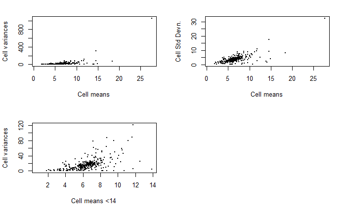

```r
plot(Means[Means <14],Vars[Means <14], xlab="Cell means <14", ylab="Cell variances", pch=19, cex=.2)
plot(Means[Means <14],SD[Means <14], xlab="Cell means <14", ylab="Cell Std Devn.", pch=19, cex=.2)
```

[figure not shown]

```r
par(mfrow=c(2,2))
plot(fitmodel)
```

There is a strong deviation from normality of the residuals. Let’s transform the response variable.

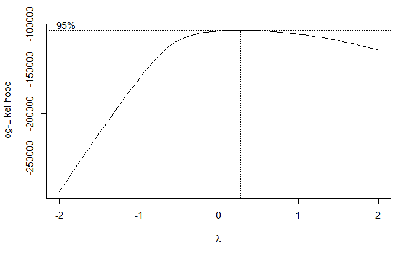

```r
library(MASS)
library(nortest)
bc <- boxcox(Crash_Score~.,data=df)
```

```r
(lambda=bc$x[which.max(bc$y)])
```

```
[1] 0.2626
```

[figure not shown]

```r
m=list()
m[[1]]= lm(Crash_Score~., data=df)
m[[2]]= lm((Crash_Score^lambda-1)/lambda ~., data=df)

par(mfrow=c(1,2))
plot(m[[1]], which=2, pch=19, cex=.25)
plot(m[[2]], which=2, pch=19, cex=.25)
```

It is clear that the boxcox power transformed response variable satisfies the normality assumption better than the original scale of Crash_Score. Let’s explore now the significance of each predictor variable.

```r
summary(m[[2]])
```

```
Call:
lm(formula = (Crash_Score^lambda - 1)/lambda ~ ., data = df)

Residuals:
   Min     1Q Median     3Q    Max
-5.036 -0.688  0.008  0.692  4.877

Coefficients:
                                           Estimate Std. Error t value Pr(>|t|)
(Intercept)                                 1.89861    0.05004   37.94  < 2e-16 ***
Time_of_Day2                                0.14473    0.04448    3.25  0.00114 **
Time_of_Day3                                0.22268    0.03930    5.67  1.5e-08 ***
Time_of_Day4                                0.21555    0.03844    5.61  2.1e-08 ***
Time_of_Day5                                0.25014    0.03853    6.49  8.7e-11 ***
Time_of_Day6                                0.15824    0.04213    3.76  0.00017 ***
Rd_FeatureINTERSECTION                      0.06943    0.02943    2.36  0.01833 *
Rd_FeatureNONE                             -0.01274    0.02367   -0.54  0.59051
Rd_FeatureOTHER                            -0.08529    0.06893   -1.24  0.21592
Rd_FeatureRAMP                             -0.08624    0.04788   -1.80  0.07171 .
Rd_ConfigurationTWO-WAY-NO-MEDIAN           0.00459    0.03102    0.15  0.88234
Rd_ConfigurationTWO-WAY-PROTECTED-MEDIAN    0.08647    0.03548    2.44  0.01479 *
Rd_ConfigurationTWO-WAY-UNPROTECTED-MEDIAN  0.03497    0.03253    1.07  0.28244
Rd_ConfigurationUNKNOWN                     0.04603    0.14119    0.33  0.74440
Traffic_ControlOTHER                        0.06966    0.06999    1.00  0.31962
Traffic_ControlSIGNAL                       0.14585    0.02072    7.04  2.0e-12 ***
Traffic_ControlSTOP-SIGN                    0.12530    0.02598    4.82  1.4e-06 ***
Traffic_ControlYIELD                        0.08280    0.06730    1.23  0.21859
---
Signif. codes:  0 ‘***’ 0.001 ‘**’ 0.01 ‘*’ 0.05 ‘.’ 0.1 ‘ ’ 1

Residual standard error: 1.03 on 23119 degrees of freedom
Multiple R-squared:  0.0124,    Adjusted R-squared:  0.0117
F-statistic: 17.1 on 17 and 23119 DF,  p-value: <2e-16
```

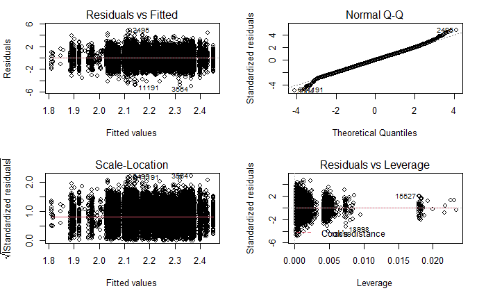

```r
par(mfrow=c(2,2))
plot(m[[2]])
```

We observe that the F statistic is greater than 1 and its p value certainly less than 0.05, therefore, we can be sure that at least one predictor-dummy variable is significative, i.e., it is related to Crash_Score. In the real problem, this would mean that there exists a relationship between the average score of a crash and different categorical conditions with more than 1 level. Nevertheless, we observe that certain levels are not significant according to their individual p value. We should remember that these individual p values provide information about whether each individual predictor is related to the response, after adjusting for the other predictors.

### A small digression on comparing models and selecting variables.

The drop1() function compares all possible models that can be constructed by dropping a single model term. The add1() function compares all possible models that can be constructed by adding a term. The step() function does repeated drop1() and add1() until the optimal AIC value is reached. The anova() function is similar to the drop1() and add1() functions. The difference is that anova takes as parameters the models to be compared instead of the models being generated by the function. That is, to use anova(), the models must be built by the user first.

```r
drop1(m[[2]],test='F')
```

```
Single term deletions

Model:
(Crash_Score^lambda - 1)/lambda ~ Time_of_Day + Rd_Feature +
    Rd_Configuration + Traffic_Control
                 Df Sum of Sq   RSS  AIC F value  Pr(>F)
<none>                        24645 1497
Time_of_Day       5      60.2 24706 1544   11.30 6.6e-11 ***
Rd_Feature        4      26.8 24672 1514    6.28 4.8e-05 ***
Rd_Configuration  4      15.4 24661 1504    3.61  0.0061 **
Traffic_Control   4      57.7 24703 1543   13.53 5.1e-11 ***
---
Signif. codes:  0 ‘***’ 0.001 ‘**’ 0.01 ‘*’ 0.05 ‘.’ 0.1 ‘ ’ 1
```

It seems that all the variables are significant according to the F test used in drop1 because they compare how good the model with full variables fit the data compared to the model without one specific predictor. If the p value is small as it is in this case, then we can say that those variables have an important effect. Now we reduce the number of levels where possible and reasonable to do so.

```r
levels(df$Rd_Feature)[4:5] = "Rd_Feature_OtherRamp"
table(df$Rd_Feature)

m[[3]] <- lm((Crash_Score^lambda-1)/lambda ~ .,data=df)
```

[output not shown]

```r
anova(m[[2]], m[[3]])
```

```
Analysis of Variance Table

Model 1: (Crash_Score^lambda - 1)/lambda ~ Time_of_Day + Rd_Feature +
    Rd_Configuration + Traffic_Control
Model 2: (Crash_Score^lambda - 1)/lambda ~ Time_of_Day + Rd_Feature +
    Rd_Configuration + Traffic_Control
  Res.Df   RSS Df Sum of Sq  F Pr(>F)
1  23119 24645
2  23120 24645 -1  -0.00016  0   0.99
```

We don’t have enough evidence against the null hypotheses, therefore, the model with less levels in the Rd_Feature predictor is not worse than the full original one.

```r
print(summary(m[[3]]), digits=2)
```

```
Call:
lm(formula = (Crash_Score^lambda - 1)/lambda ~ ., data = df)

Residuals:
   Min     1Q Median     3Q    Max
 -5.04  -0.69   0.01   0.69   4.88

Coefficients:
                                           Estimate Std. Error t value Pr(>|t|)
(Intercept)                                  1.8986     0.0498    38.1   <2e-16 ***
Time_of_Day2                                 0.1447     0.0445     3.3    0.001 **
Time_of_Day3                                 0.2227     0.0393     5.7    1e-08 ***
Time_of_Day4                                 0.2155     0.0384     5.6    2e-08 ***
Time_of_Day5                                 0.2501     0.0385     6.5    9e-11 ***
Time_of_Day6                                 0.1582     0.0421     3.8    2e-04 ***
Rd_FeatureINTERSECTION                       0.0694     0.0294     2.4    0.018 *
Rd_FeatureNONE                              -0.0127     0.0237    -0.5    0.590
Rd_FeatureRd_Feature_OtherRamp              -0.0860     0.0421    -2.0    0.041 *
Rd_ConfigurationTWO-WAY-NO-MEDIAN            0.0047     0.0304     0.2    0.878
Rd_ConfigurationTWO-WAY-PROTECTED-MEDIAN     0.0865     0.0350     2.5    0.013 *
Rd_ConfigurationTWO-WAY-UNPROTECTED-MEDIAN   0.0350     0.0319     1.1    0.272
Rd_ConfigurationUNKNOWN                      0.0461     0.1410     0.3    0.743
Traffic_ControlOTHER                         0.0698     0.0694     1.0    0.315
Traffic_ControlSIGNAL                        0.1458     0.0205     7.1    1e-12 ***
Traffic_ControlSTOP-SIGN                     0.1253     0.0259     4.8    1e-06 ***
Traffic_ControlYIELD                         0.0827     0.0670     1.2    0.217
---
Signif. codes:  0 ‘***’ 0.001 ‘**’ 0.01 ‘*’ 0.05 ‘.’ 0.1 ‘ ’ 1

Residual standard error: 1 on 23120 degrees of freedom
Multiple R-squared:  0.012, Adjusted R-squared:  0.012
F-statistic:  18 on 16 and 23120 DF,  p-value: <2e-16
```

```r
drop1(m[[2]],test='F')
```

```
Single term deletions

Model:
(Crash_Score^lambda - 1)/lambda ~ Time_of_Day + Rd_Feature +
    Rd_Configuration + Traffic_Control
                 Df Sum of Sq   RSS  AIC F value  Pr(>F)
<none>                        24645 1497
Time_of_Day       5      60.2 24706 1544   11.30 6.6e-11 ***
Rd_Feature        4      26.8 24672 1514    6.28 4.8e-05 ***
Rd_Configuration  4      15.4 24661 1504    3.61  0.0061 **
Traffic_Control   4      57.7 24703 1543   13.53 5.1e-11 ***
---
Signif. codes:  0 ‘***’ 0.001 ‘**’ 0.01 ‘*’ 0.05 ‘.’ 0.1 ‘ ’ 1
```

```r
levels(df$Time_of_Day)[3:5] <- "Time_of_Day3:5"
table(df$Time_of_Day)
```

```
             1              2 Time_of_Day3:5              6
           808           1627          18345           2357
```

```r
levels(df$Time_of_Day)[c(2,4)] <- "Time_of_Day2,6"
table(df$Time_of_Day)
```

```
             1 Time_of_Day2,6 Time_of_Day3:5
           808           3984          18345
```

```r
m[[4]] <- lm((Crash_Score^lambda-1)/lambda ~ .,data=df)
anova(m[[3]], m[[4]])
```

```
Analysis of Variance Table

Model 1: (Crash_Score^lambda - 1)/lambda ~ Time_of_Day + Rd_Feature +
    Rd_Configuration + Traffic_Control
Model 2: (Crash_Score^lambda - 1)/lambda ~ Time_of_Day + Rd_Feature +
    Rd_Configuration + Traffic_Control
  Res.Df   RSS Df Sum of Sq    F Pr(>F)
1  23120 24645
2  23123 24650 -3     -4.53 1.42   0.24
```

```r
summary(m[[4]])
```

```
Call:
lm(formula = (Crash_Score^lambda - 1)/lambda ~ ., data = df)

Residuals:
   Min     1Q Median     3Q    Max
-5.051 -0.689  0.007  0.691  4.872

Coefficients:
                                           Estimate Std. Error t value Pr(>|t|)
(Intercept)                                 1.89618    0.04981   38.07  < 2e-16 ***
Time_of_DayTime_of_Day2,6                   0.15271    0.03987    3.83  0.00013 ***
Time_of_DayTime_of_Day3:5                   0.22992    0.03716    6.19  6.2e-10 ***
Rd_FeatureINTERSECTION                      0.07111    0.02937    2.42  0.01548 *
Rd_FeatureNONE                             -0.01163    0.02365   -0.49  0.62290
Rd_FeatureRd_Feature_OtherRamp             -0.08471    0.04206   -2.01  0.04401 *
Rd_ConfigurationTWO-WAY-NO-MEDIAN           0.00576    0.03044    0.19  0.84987
Rd_ConfigurationTWO-WAY-PROTECTED-MEDIAN    0.08967    0.03494    2.57  0.01028 *
Rd_ConfigurationTWO-WAY-UNPROTECTED-MEDIAN  0.03660    0.03192    1.15  0.25152
Rd_ConfigurationUNKNOWN                     0.05030    0.14094    0.36  0.72118
Traffic_ControlOTHER                        0.06926    0.06936    1.00  0.31804
Traffic_ControlSIGNAL                       0.14517    0.02051    7.08  1.5e-12 ***
Traffic_ControlSTOP-SIGN                    0.12457    0.02593    4.80  1.6e-06 ***
Traffic_ControlYIELD                        0.08150    0.06704    1.22  0.22413
---
Signif. codes:  0 ‘***’ 0.001 ‘**’ 0.01 ‘*’ 0.05 ‘.’ 0.1 ‘ ’ 1

Residual standard error: 1.03 on 23123 degrees of freedom
Multiple R-squared:  0.0123,    Adjusted R-squared:  0.0117
F-statistic: 22.1 on 13 and 23123 DF,  p-value: <2e-16
```

```r
drop1(m[[4]],test='F')
```

```
Single term deletions

Model:
(Crash_Score^lambda - 1)/lambda ~ Time_of_Day + Rd_Feature +
    Rd_Configuration + Traffic_Control
                 Df Sum of Sq   RSS  AIC F value  Pr(>F)
<none>                        24650 1493
Time_of_Day       2      55.8 24706 1542   26.16 4.5e-12 ***
Rd_Feature        3      27.0 24677 1513    8.45 1.3e-05 ***
Rd_Configuration  4      16.3 24666 1501    3.82  0.0041 **
Traffic_Control   4      58.2 24708 1540   13.64 4.1e-11 ***
---
Signif. codes:  0 ‘***’ 0.001 ‘**’ 0.01 ‘*’ 0.05 ‘.’ 0.1 ‘ ’ 1
```

```r
levels(df$Rd_Feature)[c(1,3)] <- 'Rd_FeatureDriveNone'
table(df$Rd_Feature)
```

```
 Rd_FeatureDriveNone         INTERSECTION Rd_Feature_OtherRamp
               15398                 6702                 1037
```

```r
levels(df$Rd_Configuration)[c(1,2,4,5)] <- "Rd_Config_reference"
table(df$Rd_Configuration)
```

```
     Rd_Config_reference TWO-WAY-PROTECTED-MEDIAN
                   20510                     2627
```

```r
levels(df$Traffic_Control)[c(1,2,5)] <- 'Traffic_Control_ref'
table(df$Traffic_Control)
```

```
Traffic_Control_ref              SIGNAL           STOP-SIGN
              14516                6352                2269
```

```r
m[[5]] <- lm((Crash_Score^lambda-1)/lambda ~ .,data=df)
anova(m[[4]], m[[5]])
```

```
Analysis of Variance Table

Model 1: (Crash_Score^lambda - 1)/lambda ~ Time_of_Day + Rd_Feature +
    Rd_Configuration + Traffic_Control
Model 2: (Crash_Score^lambda - 1)/lambda ~ Time_of_Day + Rd_Feature +
    Rd_Configuration + Traffic_Control
  Res.Df   RSS Df Sum of Sq    F Pr(>F)
1  23123 24650
2  23129 24657 -6     -6.86 1.07   0.38
```

```r
summary(m[[5]])
```

```
Call:
lm(formula = (Crash_Score^lambda - 1)/lambda ~ ., data = df)

Residuals:
   Min     1Q Median     3Q    Max
-5.039 -0.689  0.008  0.691  4.867

Coefficients:
                                         Estimate Std. Error t value Pr(>|t|)
(Intercept)                                1.8997     0.0367   51.70  < 2e-16 ***
Time_of_DayTime_of_Day2,6                  0.1541     0.0399    3.87  0.00011 ***
Time_of_DayTime_of_Day3:5                  0.2308     0.0371    6.21  5.2e-10 ***
Rd_FeatureINTERSECTION                     0.0911     0.0197    4.62  3.9e-06 ***
Rd_FeatureRd_Feature_OtherRamp            -0.0659     0.0337   -1.95  0.05087 .
Rd_ConfigurationTWO-WAY-PROTECTED-MEDIAN   0.0731     0.0215    3.40  0.00069 ***
Traffic_ControlSIGNAL                      0.1458     0.0197    7.42  1.2e-13 ***
Traffic_ControlSTOP-SIGN                   0.1206     0.0257    4.69  2.7e-06 ***
---
Signif. codes:  0 ‘***’ 0.001 ‘**’ 0.01 ‘*’ 0.05 ‘.’ 0.1 ‘ ’ 1

Residual standard error: 1.03 on 23129 degrees of freedom
Multiple R-squared:  0.012, Adjusted R-squared:  0.0117
F-statistic: 40.1 on 7 and 23129 DF,  p-value: <2e-16
```

```r
drop1(m[[5]],test='F')
```

```
Single term deletions

Model:
(Crash_Score^lambda - 1)/lambda ~ Time_of_Day + Rd_Feature +
    Rd_Configuration + Traffic_Control
                 Df Sum of Sq   RSS  AIC F value  Pr(>F)
<none>                        24657 1488
Time_of_Day       2      55.9 24713 1536    26.2 4.2e-12 ***
Rd_Feature        2      32.3 24689 1514    15.2 2.7e-07 ***
Rd_Configuration  1      12.3 24669 1497    11.5 0.00069 ***
Traffic_Control   2      62.4 24719 1542    29.3 2.0e-13 ***
---
Signif. codes:  0 ‘***’ 0.001 ‘**’ 0.01 ‘*’ 0.05 ‘.’ 0.1 ‘ ’ 1
```

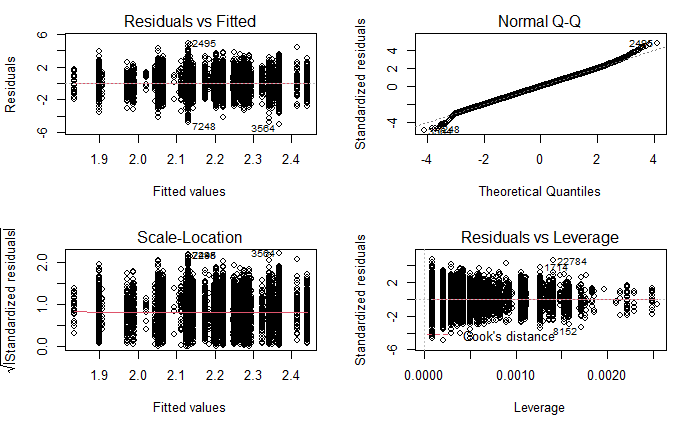

```r
par(mfrow=c(2,2))
plot(m[[5]])
```

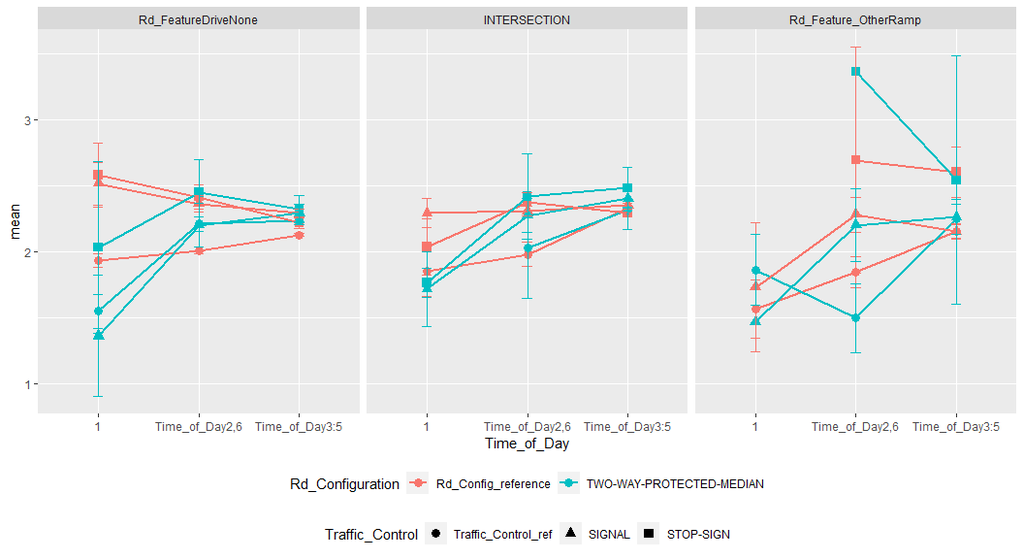

```r
library(ggplot2)
library(dplyr)
plotdata <- df %>%
  group_by(Time_of_Day, Rd_Configuration,Traffic_Control,Rd_Feature) %>%
  summarize(n = n(),
            mean = mean((Crash_Score^lambda-1)/lambda),
            sd = sd((Crash_Score^lambda-1)/lambda),
            se = sd/sqrt(n))
ggplot(plotdata, aes(x = Time_of_Day,
                     y = mean,
                     group=interaction(Rd_Configuration,Traffic_Control),
                     shape=Traffic_Control,
                     color=Rd_Configuration)) +
  geom_point(size = 3) +
  geom_line(size = 1) +
  geom_errorbar(aes(ymin  =mean - se,
                    ymax = mean+se),
                width = .1) +
  facet_wrap(~Rd_Feature)+
  theme(legend.position = 'bottom',legend.box = "vertical")+
  ggsave(file="thumb.jpg", width=15, height=7,dpi=500)
```